# Plot Grouped Data: Box plot, Bar Plot and More

> refer from: http://www.sthda.com/english/articles/32-r-graphics-essentials/132-plot-grouped-data-box-plot-bar-plot-and-more/

# 01. 所需要的包

并设置默认主题为**theme_pubclean()**

```r
library(dplyr)
library(ggplot2)
library(ggpubr)
theme_set(theme_pubclean())
```

# 02.画barplot 和 dotplot 图

- 示例数据集 diamonds (ggplot2)
- 只要颜色是的 J 和 D的部分。
- 以 cut 和 color 为分组变量，画 barplot, dotplot等图

## 1. 过滤数据并分组计数

| cut | color | counts |
| --- | --- | --- |
| Fair | D | 163 |
| Fair | J | 119 |
| Good | D | 662 |
| Good | J | 307 |

## 2.画分组barplot图

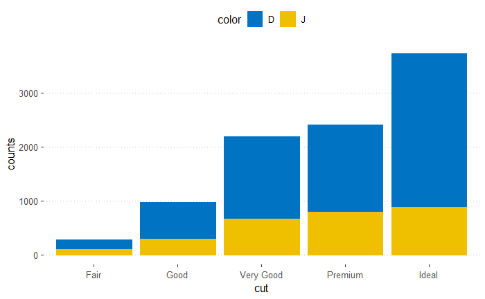

```r
# Stacked bar plots of y = counts by x = cut,
# colored by the variable color
ggplot(df, aes(x = cut, y = counts)) +
  geom_bar(
    aes(color = color, fill = color),
    stat = "identity", position = position_stack()
    ) +
  scale_color_manual(values = c("#0073C2FF", "#EFC000FF"))+
  scale_fill_manual(values = c("#0073C2FF", "#EFC000FF"))
```

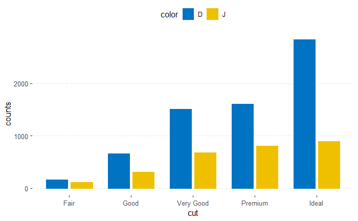

```r
# Use position = position_dodge()
p <- ggplot(df, aes(x = cut, y = counts)) +
  geom_bar(
    aes(color = color, fill = color),
    stat = "identity", position = position_dodge(0.8),
    width = 0.7
    ) +
  scale_color_manual(values = c("#0073C2FF", "#EFC000FF"))+
  scale_fill_manual(values = c("#0073C2FF", "#EFC000FF"))
p
```

> Note that, position_stack() automatically stack values in reverse order of the group aesthetic. This default ensures that bar colors align with the default legend. You can change this behavior by using position = position_stack(reverse = TRUE).

## 3.画分组dotplot图

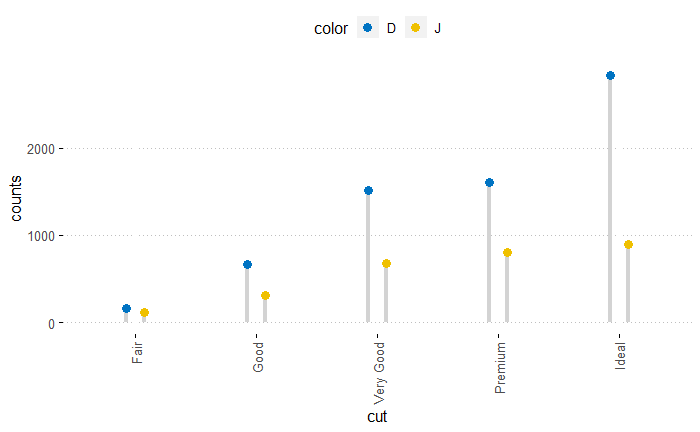

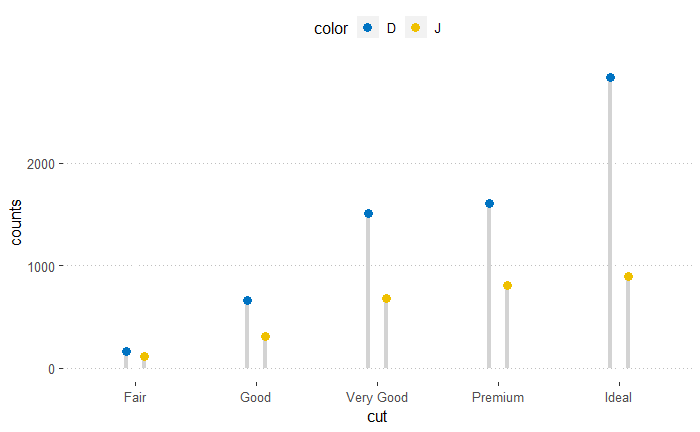

## 04. 在barplot上增加文字标签

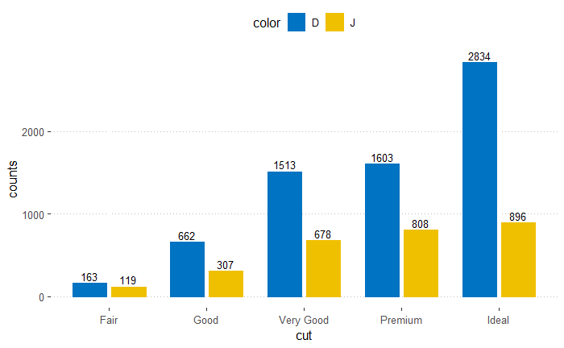

## 05. 在堆叠的柱状图上增加文字标签

| cut | color | counts | lab_ypos |
| --- | --- | --- | --- |
| Fair | J | 119 | 59.5 |
| Fair | D | 163 | 200.5 |
| Good | J | 307 | 153.5 |
| Good | D | 662 | 638.0 |

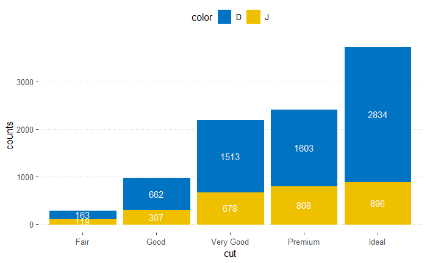

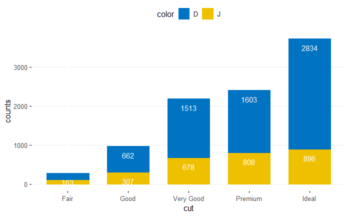

## 06. jitter 抖动图

> Instead of the creating a bar plot of the counts, you can plot two discrete variables with discrete x-axis and discrete y-axis. Each individual points are shown by groups. For a given group, the number of points corresponds to the number of records in that group. Key function: geom_jitter(). Arguments: alpha, color, fill, shape and size.

> In the example below, we’ll plot a small fraction (1/5) of the diamonds dataset.

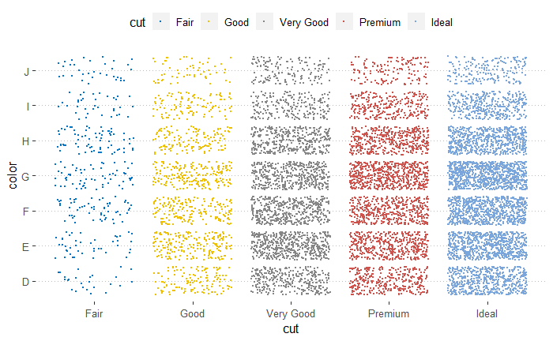

# 03. 画boxplot 小提琴图等

- 数据

```r
data("ToothGrowth")
ToothGrowth$dose <- as.factor(ToothGrowth$dose)
head(ToothGrowth)
```

|  | len | supp | dose |
| --- | --- | --- | --- |
| 1 | 4.2 | VC | 0.5 |
| 2 | 11.5 | VC | 0.5 |
| 3 | 7.3 | VC | 0.5 |
| 4 | 5.8 | VC | 0.5 |
| 5 | 6.4 | VC | 0.5 |
| 6 | 10.0 | VC | 0.5 |

## 01. Box plots

- Key function: geom_boxplot()
- Key arguments to customize the plot:
  - width: the width of the box plot
  - notch: logical. If TRUE, creates a notched box plot. The notch displays a confidence interval around the median which is normally based on the median +/- 1.58*IQR/sqrt(n). Notches are used to compare groups; if the notches of two boxes do not overlap, this is a strong evidence that the medians differ.
  - color, size, linetype: Border line color, size and type
  - fill: box plot areas fill color
  - outlier.colour, outlier.shape, outlier.size: The color, the shape and the size for outlying points.

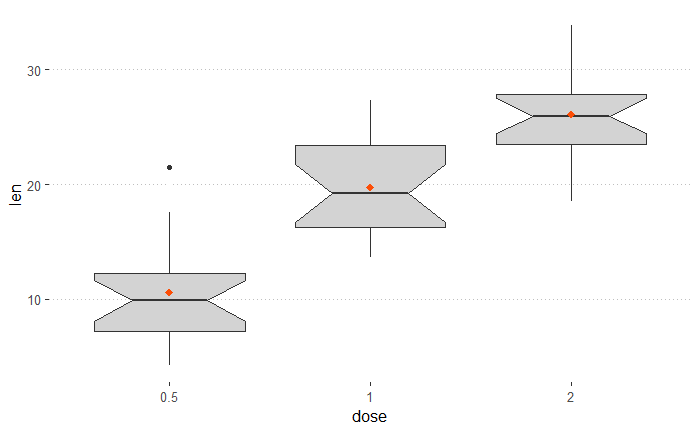

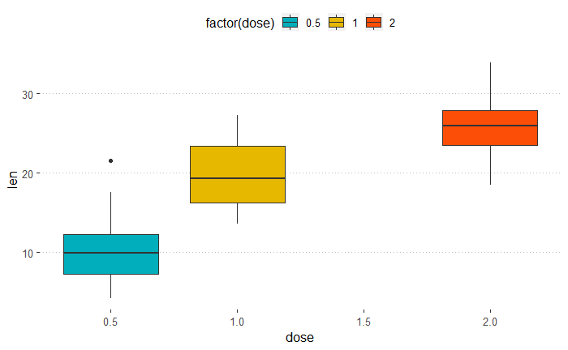

## 02. 分组Box plots

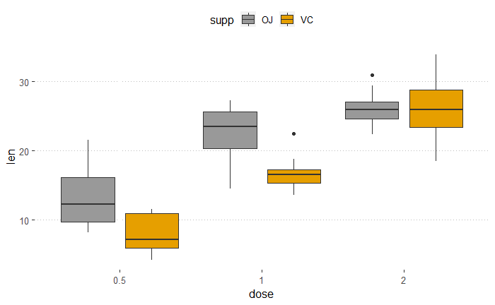

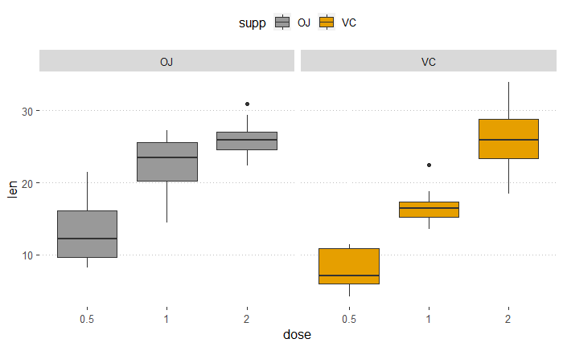

## 03.Violin plots

Key function:

- geom_violin(): Creates violin plots. Key arguments:
  - color, size, linetype: Border line color, size and type
  - fill: Areas fill color
  - trim: logical value. If TRUE (default), trim the tails of the violins to the range of the data. If FALSE, don’t trim the tails.
- stat_summary(): Adds summary statistics (mean, median, …) on the violin plots.

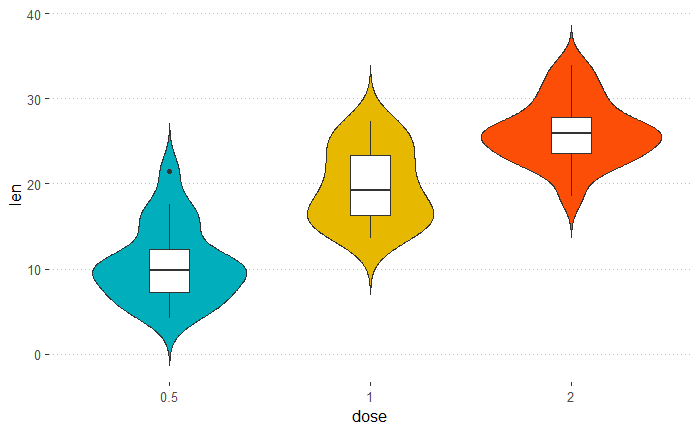

[figure not shown]

```r
  ggplot(ToothGrowth, aes(x = dose, y = len)) +
  geom_violin(aes(color = supp), trim = FALSE,position = position_dodge(0.6) ) +
  geom_jitter(aes(color=supp),alpha=0.6,
              position = position_jitterdodge(jitter.width = 0.2, dodge.width = 0.6))+
  stat_summary(
    aes(group = supp),
    fun.data="mean_sdl",  fun.args = list(mult=1),
    geom = "pointrange",  size = 0.6,color="red",
    position = position_dodge(0.6)
  )+
  scale_color_manual(values =  c("#00AFBB", "#E7B800"))
```

## 04 Dot plots

- Key function: geom_dotplot(). Creates stacked dots, with each dot representing one observation.
- Key arguments:
  - stackdir: which direction to stack the dots. “up” (default), “down”, “center”, “centerwhole” (centered, but with dots aligned).
  - sstackratio: how close to stack the dots. Default is 1, where dots just just touch. Use smaller values for closer, overlapping dots.
  - scolor, fill: Dot border color and area fill
  - sdotsize: The diameter of the dots relative to binwidth, default 1.

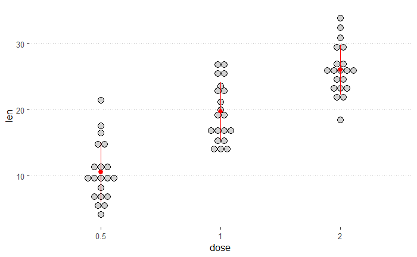

```r
 ggplot(ToothGrowth, aes(x = dose, y = len)) +
   geom_dotplot(binaxis = "y", stackdir = "center",fill = "lightgray") +
  stat_summary( fun.data = "mean_sdl", fun.args = list(mult=1),
                geom = "pointrange", color = "red")
```

```r
# Color dots by groups
e + geom_boxplot(width = 0.5, size = 0.4) +
  geom_dotplot(
    aes(fill = supp),
    binaxis='y', stackdir='center'
  )+
  scale_fill_manual(values = c("#00AFBB", "#E7B800"))
# Change the position : interval between dot plot of the same group
e + geom_boxplot(
  aes(color = supp), width = 0.5, size = 0.4,
  position = position_dodge(0.8)
  ) +
  geom_dotplot(
    aes(fill = supp, color = supp),
    binaxis='y', stackdir='center', dotsize = 0.8,
    position = position_dodge(0.8)
  )+
  scale_fill_manual(values = c("#00AFBB", "#E7B800"))+
  scale_color_manual(values = c("#00AFBB", "#E7B800"))
```

## 05 Stripcharts

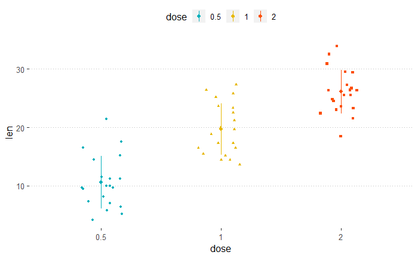

```r
e + geom_jitter(
  aes(shape = dose, color = dose),
  position = position_jitter(0.2),
  size = 1.2
  ) +
  stat_summary(
    aes(color = dose),
    fun.data="mean_sdl",  fun.args = list(mult=1),
    geom = "pointrange",  size = 0.4
    )+
  scale_color_manual(values =  c("#00AFBB", "#E7B800", "#FC4E07"))
```

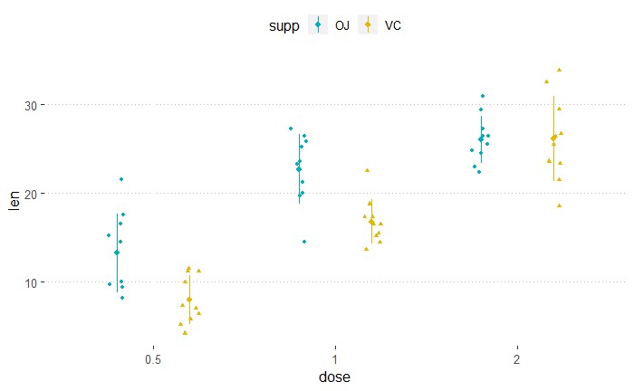

```r
e + geom_jitter(
  aes(shape = supp, color = supp),
  position = position_jitterdodge(jitter.width = 0.2, dodge.width = 0.8),
  size = 1.2
  ) +
  stat_summary(
    aes(color = supp),
    fun.data="mean_sdl",  fun.args = list(mult=1),
    geom = "pointrange",  size = 0.4,
    position = position_dodge(0.8)
    )+
  scale_color_manual(values =  c("#00AFBB", "#E7B800"))
```

## 06 Sinaplot

sinaplot is inspired by the strip chart and the violin plot. By letting the normalized density of points restrict the jitter along the x-axis, the plot displays the same contour as a violin plot, but resemble a simple strip chart for small number of data points (Sidiropoulos et al. 2015).

In this way the plot conveys information of both the number of data points, the density distribution, outliers and spread in a very simple, comprehensible and condensed format.

Key function: geom_sina() [ggforce]:

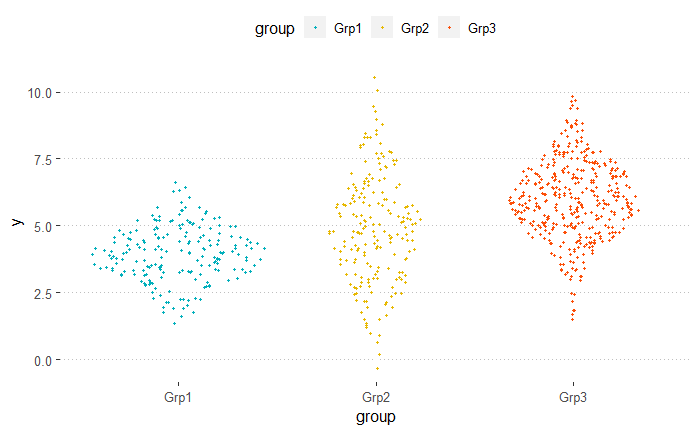

## 07 Mean and median plots with error bars

|  | len | supp | dose |
| --- | --- | --- | --- |
| 1 | 4.2 | VC | 0.5 |
| 2 | 11.5 | VC | 0.5 |
| 3 | 7.3 | VC | 0.5 |

| dose | sd | len |
| --- | --- | --- |
| 0.5 | 4.499763 | 10.605 |
| 1 | 4.415436 | 19.735 |
| 2 | 3.774150 | 26.100 |

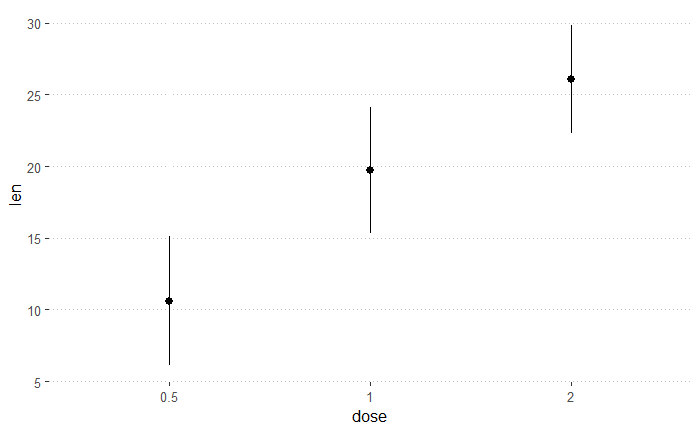

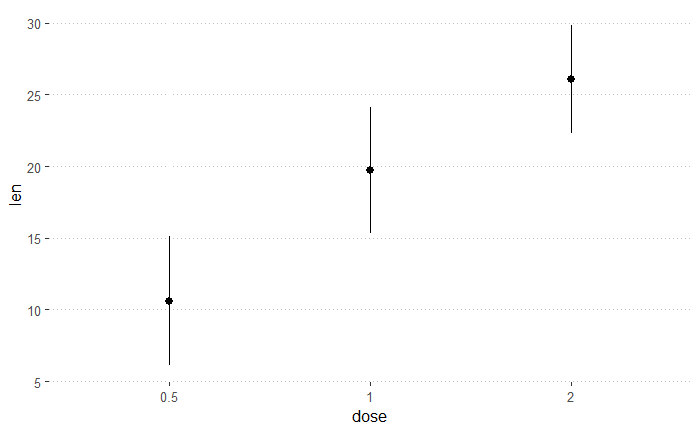

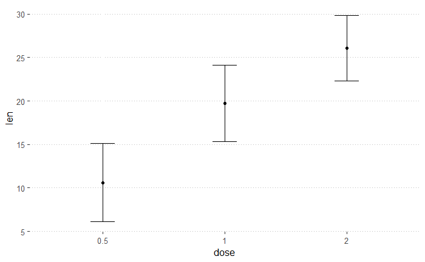

```r
# Vertical line with point in the middle
f + geom_pointrange()
# Vertical line with point in the middle
f + geom_pointrange()

# Standard error bars
f + geom_errorbar(width = 0.2) +
  geom_point(size = 1.5)
```

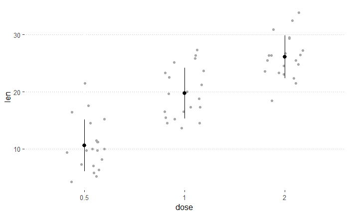

```r
# Combine with jitter points
ggplot(df, aes(dose, len)) +
  geom_jitter(
    position = position_jitter(0.2), color = "darkgray"
    ) +
  geom_pointrange(
    aes(ymin = len-sd, ymax = len+sd),
    data = df.summary
    )
```

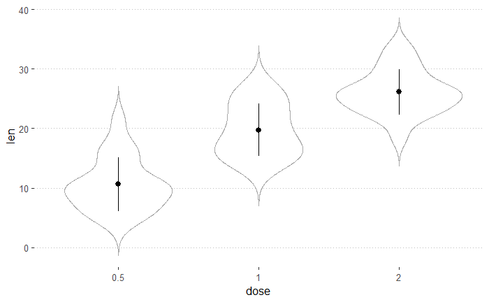

```r
# Combine with violin plots
ggplot(df, aes(dose, len)) +
  geom_violin(color = "darkgray", trim = FALSE) +
  geom_pointrange(
    aes(ymin = len-sd, ymax = len+sd),
    data = df.summary
    )
```

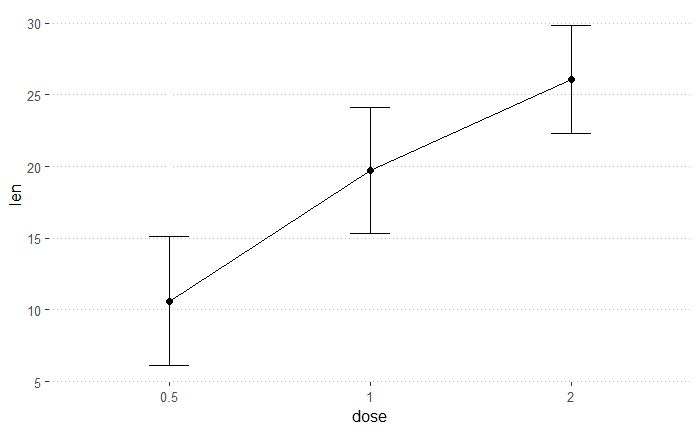

```r
# (1) Line plot
ggplot(df.summary, aes(dose, len)) +
  geom_line(aes(group = 1)) +
  geom_errorbar( aes(ymin = len-sd, ymax = len+sd),width = 0.2) +
  geom_point(size = 2)
```

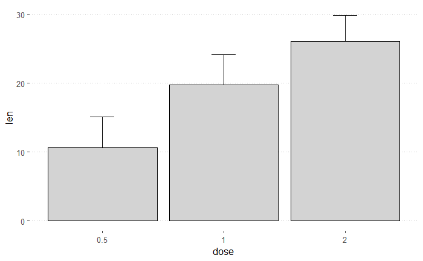

```r
# (2) Bar plot
ggplot(df.summary, aes(dose, len)) +
  geom_bar(stat = "identity", fill = "lightgray",
           color = "black") +
  geom_errorbar(aes(ymin = len, ymax = len+sd), width = 0.2)
```

For line plot, you might want to treat x-axis as numeric:

```r
df.sum2 <- df.summary
df.sum2$dose <- as.numeric(df.sum2$dose)
ggplot(df.sum2, aes(dose, len)) +
  geom_line() +
  geom_errorbar( aes(ymin = len-sd, ymax = len+sd),width = 0.2) +
  geom_point(size = 2)
```

Bar and line plots + jitter points. We need the original df data for the jitter points and the df.summary data for the other geom layers. For the line plot: First, add jitter points, then add lines + error bars + mean points on top of the jitter points. For the bar plot: First, add the bar plot, then add jitter points + error bars on top of the bars.

```r
# (1) Create a line plot of means +
# individual jitter points + error bars
ggplot(df, aes(dose, len)) +
  geom_jitter( position = position_jitter(0.2),
               color = "darkgray") +
  geom_line(aes(group = 1), data = df.summary) +
  geom_errorbar(
    aes(ymin = len-sd, ymax = len+sd),
    data = df.summary, width = 0.2) +
  geom_point(data = df.summary, size = 2)
# (2) Bar plots of means + individual jitter points + errors
ggplot(df, aes(dose, len)) +
  geom_bar(stat = "identity", data = df.summary,
           fill = NA, color = "black") +
  geom_jitter( position = position_jitter(0.2),
               color = "black") +
  geom_errorbar(
    aes(ymin = len-sd, ymax = len+sd),
    data = df.summary, width = 0.2)
```

### Mean/median plots for multiple groups

```r
library(dplyr)
df.summary2 <- df %>%
  group_by(dose, supp) %>%
  summarise(
    sd = sd(len),
    len = mean(len)
  )
df.summary2
```

```r
# (1) Pointrange: Vertical line with point in the middle
ggplot(df.summary2, aes(dose, len)) +
  geom_pointrange(
    aes(ymin = len-sd, ymax = len+sd, color = supp),
    position = position_dodge(0.3)
    )+
  scale_color_manual(values = c("#00AFBB", "#E7B800"))
# (2) Standard error bars
ggplot(df.summary2, aes(dose, len)) +
  geom_errorbar(
    aes(ymin = len-sd, ymax = len+sd, color = supp),
    position = position_dodge(0.3), width = 0.2
    )+
  geom_point(aes(color = supp), position = position_dodge(0.3)) +
  scale_color_manual(values = c("#00AFBB", "#E7B800"))
```

```r
# (1) Line plot + error bars
ggplot(df.summary2, aes(dose, len)) +
  geom_line(aes(linetype = supp, group = supp))+
  geom_point()+
  geom_errorbar(
    aes(ymin = len-sd, ymax = len+sd, group = supp),
     width = 0.2
    )
# (2) Bar plots + upper error bars.
ggplot(df.summary2, aes(dose, len)) +
  geom_bar(aes(fill = supp), stat = "identity",
           position = position_dodge(0.8), width = 0.7)+
  geom_errorbar(
    aes(ymin = len, ymax = len+sd, group = supp),
    width = 0.2, position = position_dodge(0.8)
    )+
  scale_fill_manual(values = c("grey80", "grey30"))
```

Create easily plots of mean +/- sd for multiple groups. Use the ggpubr package, which will automatically calculate the summary statistics and create the graphs.

```r
library(ggpubr)
# Create line plots of means
ggline(ToothGrowth, x = "dose", y = "len",
       add = c("mean_sd", "jitter"),
       color = "supp", palette = c("#00AFBB", "#E7B800"))
# Create bar plots of means
ggbarplot(ToothGrowth, x = "dose", y = "len",
          add = c("mean_se", "jitter"),
          color = "supp", palette = c("#00AFBB", "#E7B800"),
          position = position_dodge(0.8))
```

```r
# Create line plots
ggplot(df, aes(dose, len)) +
  geom_jitter(
    aes(color = supp),
    position = position_jitter(0.2)
    ) +
  geom_line(
    aes(group = supp, color = supp),
    data = df.summary2
    ) +
  geom_errorbar(
    aes(ymin = len-sd, ymax = len+sd, color = supp),
    data = df.summary2, width = 0.2
    )+
  scale_color_manual(values = c("#00AFBB", "#E7B800"))
```

### Add p-values and significance levels

In this section, we’ll describe how to easily i) compare means of two or multiple groups; ii) and to automatically add p-values and significance levels to a ggplot (such as box plots, dot plots, bar plots and line plots, …).

Key functions:

- `compare_means()`
  $$ggpubr package$$
  : easy to use solution to performs one and multiple mean comparisons.
- `stat_compare_means()`
  $$ggpubr package$$
  : easy to use solution to automatically add p-values and significance levels to a ggplot.

The most common [methods for comparing means](http://www.sthda.com/english/wiki/comparing-means-in-r) include:

| Methods | R function | Description |
| --- | --- | --- |
| T-test | t.test() | Compare two groups (parametric) |
| Wilcoxon test | wilcox.test() | Compare two groups (non-parametric) |
| ANOVA | aov() or anova() | Compare multiple groups (parametric) |
| Kruskal-Wallis | kruskal.test() | Compare multiple groups (non-parametric) |

Compare multiple groups (non-parametric)

1. **Compare two independent groups**:
- Compute t-test:

| .y. | group1 | group2 | p | p.adj | p.format | p.signif | method |
| --- | --- | --- | --- | --- | --- | --- | --- |
| len | OJ | VC | 0.06063451 | 0.061 | 0.061 | ns | T-test |

- Create a box plot with p-values. Use the option `method = "t.test"` or `method = "wilcox.test"`. Default is wilcoxon test.

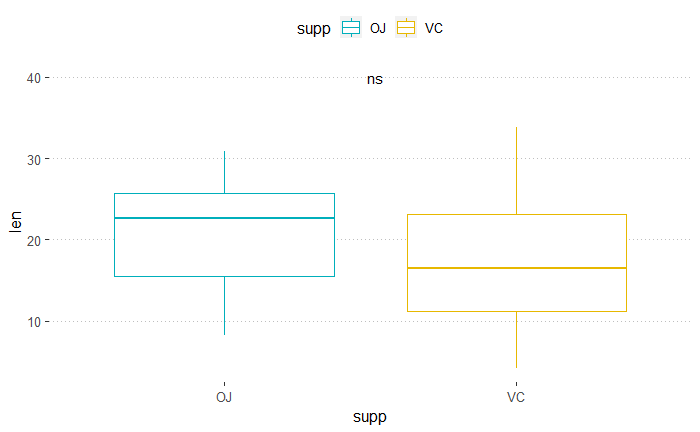

2. **Compare two paired samples**.

Use `ggpaired()`
$$ggpubr$$
to create the paired box plot.

```r
 ggpaired(ToothGrowth, x = "supp", y = "len",
             color = "supp", line.color = "gray", line.size = 0.4,
             palette = "jco")+
      stat_compare_means(paired = TRUE)
```

3. **Compare more than two groups**.

If the grouping variable contains more than two levels, then pairwise tests will be performed automatically. The default method is “wilcox.test”. You can change this to “t.test”.

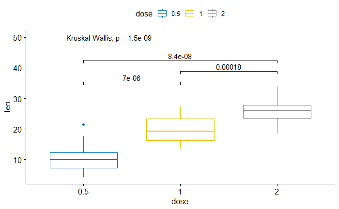

```
4.  **Multiple grouping variables**:
```

- (1/2). Create a multi-panel box plots facetted by group (here, “dose”):

```r
 # Use only p.format as label. Remove method name.
    ggplot(ToothGrowth, aes(supp, len)) +
      geom_boxplot(aes(color = supp))+
      facet_wrap(~dose) +
      scale_color_manual(values = c("#00AFBB", "#E7B800")) +
      stat_compare_means(label = "p.format")
```

- (2/2). Create one single panel with all box plots. Plot y = “len” by x = “dose” and color by “supp”. Specify the option `group` in `stat_compare_means()`:

```r
ggplot(ToothGrowth, aes(dose, len)) +
      geom_boxplot(aes(color = supp))+
      scale_color_manual(values = c("#00AFBB", "#E7B800")) +
      stat_compare_means(aes(group = supp), label = "p.signif")
```

- Paired comparisons for multiple groups:

```r
 # Box plot facetted by "dose"
    p <- ggpaired(ToothGrowth, x = "supp", y = "len",
              color = "supp", palette = "jco",
              line.color = "gray", line.size = 0.4,
              facet.by = "dose", short.panel.labs = FALSE)
    # Use only p.format as label. Remove method name.
    p + stat_compare_means(label = "p.format", paired = TRUE)
```

## # Conclusion

1. **Visualize the distribution of a grouped continuous variable**: the grouping variable on x-axis and the continuous variable on y axis.

The possible ggplot2 layers include:

- `geom_boxplot()` for box plot
- `geom_violin()` for violin plot
- `geom_dotplot()` for dot plot
- `geom_jitter()` for stripchart
- `geom_line()` for line plot
- `geom_bar()` for bar plot

Examples of R code: start by creating a plot, named `e`, and then finish it by adding a layer:

```r
 ToothGrowth$dose <- as.factor(ToothGrowth$dose)
    e <- ggplot(ToothGrowth, aes(x = dose, y = len))
```

2. **Create mean and median plots with error bars**:the grouping variable on x-axis and the summarized continuous variable (mean/median) on y-axis.
- Compute summary statistics and initialize ggplot with summary data:

```r
    # Summary statistics
    library(dplyr)
    df.summary <- ToothGrowth %>%
      group_by(dose) %>%
      summarise(
        sd = sd(len, na.rm = TRUE),
        len = mean(len)
      )
    # Initialize ggplot with data
    f <- ggplot(
      df.summary,
      aes(x = dose, y = len, ymin = len-sd, ymax = len+sd)
      )
```

3. **Combine error bars with violin plots, dot plots, line and bar plots**:

```r
 # Combine with violin plots
    ggplot(ToothGrowth, aes(dose, len))+
      geom_violin(trim = FALSE) +
      geom_pointrange(aes(ymin = len-sd, ymax = len + sd),
                      data = df.summary)
    # Combine with dot plots
    ggplot(ToothGrowth, aes(dose, len))+
      geom_dotplot(stackdir = "center", binaxis = "y",
                   fill = "lightgray", dotsize = 1) +
      geom_pointrange(aes(ymin = len-sd, ymax = len + sd),
                      data = df.summary)
    # Combine with line plot
    ggplot(df.summary, aes(dose, len))+
      geom_line(aes(group = 1)) +
      geom_pointrange(aes(ymin = len-sd, ymax = len + sd))
    # Combine with bar plots
    ggplot(df.summary, aes(dose, len))+
      geom_bar(stat = "identity", fill = "lightgray") +
      geom_pointrange(aes(ymin = len-sd, ymax = len + sd))
```

## # See also

- ggpubr: Publication Ready Plots. https://goo.gl/7uySha
- Facilitating Exploratory Data Visualization: Application to TCGA Genomic Data. https://goo.gl/9LNsRi
- Add P-values and Significance Levels to ggplots. https://goo.gl/VH7Yq7
- Plot Means/Medians and Error Bars. https://goo.gl/zRwAeV

Read more at: [Add P-values and Significance Levels to ggplots](http://www.sthda.com/english/articles/24-ggpubr-publication-ready-plots/76-add-p-values-and-significance-levels-to-ggplots/)